# Group 88 - UDL Assignment 2: Part B

## WGAN and WGAN-GP with Color-Space Proxy Metric Evaluation

## Team Details

| Student Name | Student ID | Contribution | Signature / Initial |
| --- | --- | --- | --- |
| Lalit Tyagi | 2024ac05569 | 100% | LT |
| Sreejith M V | 2024AD05421 | 100% | SV |
| Ashwini N | 2024ad05029 | 100% | AN |
| Ashok Pyaram | 2024ad05197 | 100% | AP |
| Gopikannan G | 2024ac05790 | 100% | GG |

This notebook handles the training loops for both WGAN (Weight Clipping) and WGAN-GP (Gradient Penalty). It then generates 100 synthetic random samples from each model and computes the **$8 \times 8$ Color Fréchet Proxy Metric** matching the implementation in Part A to evaluate distribution alignment.

```python
import os
import math
import time
import numpy as np
import matplotlib.pyplot as plt
from tqdm import tqdm

import torch
import torch.nn as nn
import torch.nn.functional as F
from torch.utils.data import DataLoader
from torchvision import datasets, transforms
import torchvision.utils as vutils
from google.colab import drive


# --- Setup Device ---
device = torch.device("cuda" if torch.cuda.is_available() else "cpu")
print(f"Using device: {device}")


# 2. Mount cleanly to the required root path
drive.mount('/content/drive', force_remount=True)

# --- Define a dedicated folder in your Google Drive for datasets ---
# This ensures it persists across sessions so you don't have to re-download it.
drive_data_path = '/content/drive/MyDrive/datasets'
os.makedirs(drive_data_path, exist_ok=True)
saved_samples_path = '/content/drive/MyDrive/saved_samples'
os.makedirs(saved_samples_path, exist_ok=True)

# --- Pure-PyTorch Data Ingestion Engine ---
def pil_to_tensor_without_numpy(image):
    image = image.convert('RGB')
    pixels = torch.frombuffer(bytearray(image.tobytes()), dtype=torch.uint8)
    return pixels.view(image.height, image.width, 3).permute(2, 0, 1).float().div(255.0)

transform = transforms.Lambda(pil_to_tensor_without_numpy)

train_dataset = datasets.CIFAR10(root=drive_data_path, train=True, download=True, transform=transform)
test_dataset = datasets.CIFAR10(root=drive_data_path, train=False, download=True, transform=transform)

train_loader = DataLoader(train_dataset, batch_size=64, shuffle=True, num_workers=0)
test_loader = DataLoader(test_dataset, batch_size=64, shuffle=False, num_workers=0)
```

```
Using device: cuda
```

**Discussion: Ingestion Framework Stability**

- **Zero NumPy Latency:** Bypassing traditional intermediate array transformations eliminates PyTorch tensor locks during asynchronous data extraction steps.
- **Bounding Inputs:** Rescaling pixel coordinates directly to $[0, 1]$ anchors target distributions cleanly against the Sigmoid activation functions on the Generator network's output layer.

```python
# --- Identical 8x8 Color Channel Fréchet Proxy Engine (Synced with Part A) ---
def calculate_colour_frechet_proxy(real_imgs, gen_imgs, eps=1e-12):
    def features(images):
        if images.dim() == 4:
            return F.interpolate(images, size=(8, 8), mode='bilinear', align_corners=False).flatten(1)
        return images.flatten(1)

    def covariance(values):
        centered = values - values.mean(dim=0, keepdim=True)
        return centered.T @ centered / max(values.size(0) - 1, 1)

    real_features, gen_features = features(real_imgs).float(), features(gen_imgs).float()
    mu_real, mu_gen = real_features.mean(dim=0), gen_features.mean(dim=0)
    sigma_real, sigma_gen = covariance(real_features), covariance(gen_features)

    identity = torch.eye(sigma_real.size(0), device=real_imgs.device, dtype=real_imgs.dtype)
    eigenvalues, eigenvectors = torch.linalg.eigh(sigma_real + eps * identity)
    sqrt_real = (eigenvectors * eigenvalues.clamp_min(0).sqrt()) @ eigenvectors.T
    middle = sqrt_real @ (sigma_gen + eps * identity) @ sqrt_real
    trace_sqrt = torch.linalg.eigvalsh(middle).clamp_min(0).sqrt().sum()

    fid_score = (mu_real - mu_gen).pow(2).sum() + torch.trace(sigma_real + sigma_gen) - 2 * trace_sqrt
    return float(fid_score.clamp_min(0).item())

def calculate_batch_mse(img1, img2):
    return torch.mean((img1 - img2) ** 2).item()
```

```python
# --- Deep Convolutional Generator Network ---
class Generator(nn.Module):
    def __init__(self, latent_dim=128, feature_maps=64):
        super(Generator, self).__init__()
        self.net = nn.Sequential(
            nn.ConvTranspose2d(latent_dim, feature_maps * 4, 4, stride=1, padding=0, bias=False),
            nn.BatchNorm2d(feature_maps * 4),
            nn.ReLU(True),
            nn.ConvTranspose2d(feature_maps * 4, feature_maps * 2, 4, stride=2, padding=1, bias=False),
            nn.BatchNorm2d(feature_maps * 2),
            nn.ReLU(True),
            nn.ConvTranspose2d(feature_maps * 2, feature_maps, 4, stride=2, padding=1, bias=False),
            nn.BatchNorm2d(feature_maps),
            nn.ReLU(True),
            nn.ConvTranspose2d(feature_maps, 3, 4, stride=2, padding=1, bias=False),
            nn.Sigmoid()
        )

    def forward(self, z):
        return self.net(z.view(z.size(0), -1, 1, 1))

# --- Parametric Dual-Normalization Critic Architecture ---
class Critic(nn.Module):
    def __init__(self, feature_maps=64, use_batchnorm=True):
        super(Critic, self).__init__()
        norm_layer = (lambda c: nn.BatchNorm2d(c)) if use_batchnorm else (lambda c: nn.InstanceNorm2d(c, affine=True))

        self.net = nn.Sequential(
            nn.Conv2d(3, feature_maps, 4, stride=2, padding=1),
            nn.LeakyReLU(0.2, inplace=True),
            nn.Conv2d(feature_maps, feature_maps * 2, 4, stride=2, padding=1),
            norm_layer(feature_maps * 2),
            nn.LeakyReLU(0.2, inplace=True),
            nn.Conv2d(feature_maps * 2, feature_maps * 4, 4, stride=2, padding=1),
            norm_layer(feature_maps * 4),
            nn.LeakyReLU(0.2, inplace=True),
            nn.Conv2d(feature_maps * 4, 1, 4, stride=1, padding=0)
        )

    def forward(self, x):
        return self.net(x).view(-1)
```

**Discussion: Generator/Critic architecture (WGAN & WGAN-GP)**

- Generator mirrors the VAE/VQ-VAE decoders by using a 4-layer nn.Sequential block for transposed-convolution upsampling (4*4 $\rightarrow$ 8×8 $\rightarrow$ 16×16 $\rightarrow$ 32×32). A final nn.Sigmoid() head forces the pixel values into the range $[0, 1]$ to maintain a uniform output distribution across all architectures for a fair comparison in Part C.
- Critic has no sigmoid output — its final layer maps directly from feature_maps * 4 to a single channel using a $4\times4$ convolution without activation, outputting an unbounded real-valued scalar (.view(-1)) to approximate the Wasserstein distance rather than a bounded real/fake probability.
- Normalization dynamically switches based on the use_batchnorm flag: it uses standard nn.BatchNorm2d for plain WGAN but dynamically swaps to nn.InstanceNorm2d(..., affine=True) for WGAN-GP. This is a deliberate design choice because batch normalization couples samples across the batch dimension, directly breaking the per-sample 1-Lipschitz gradient penalty optimization introduced in the WGAN-GP framework.

#### Unified Training Engine for WGAN Variants

```python
def train_wgan(mode="WGAN-WC", epochs=10, latent_dim=128):
    print(f"\n=== Training {mode} Model ===")

    # Start tracking time for this variant
    start_time = time.time()

    netG = Generator(latent_dim=latent_dim).to(device)
    use_bn = True if mode == "WGAN-WC" else False
    netC = Critic(use_batchnorm=use_bn).to(device)

    if mode == "WGAN-WC":
        optimizerG = torch.optim.RMSprop(netG.parameters(), lr=5e-5)
        optimizerC = torch.optim.RMSprop(netC.parameters(), lr=5e-5)
    else: # WGAN-GP
        optimizerG = torch.optim.Adam(netG.parameters(), lr=1e-4, betas=(0.0, 0.9))
        optimizerC = torch.optim.Adam(netC.parameters(), lr=1e-4, betas=(0.0, 0.9))

    fixed_noise = torch.randn(100, latent_dim, device=device)

    for epoch in range(epochs):
        c_losses = []
        for i, (real_imgs, _) in enumerate(train_loader):
            real_imgs = real_imgs.to(device)
            b_size = real_imgs.size(0)

            # ---------------------
            # Train Critic
            # ---------------------
            optimizerC.zero_grad()
            noise = torch.randn(b_size, latent_dim, device=device)
            fake_imgs = netG(noise)

            loss_C = -torch.mean(netC(real_imgs)) + torch.mean(netC(fake_imgs.detach()))

            if mode == "WGAN-GP":
                alpha = torch.rand(b_size, 1, 1, 1, device=device)
                interpolates = (alpha * real_imgs + ((1 - alpha) * fake_imgs.detach())).requires_grad_(True)
                d_interpolates = netC(interpolates)
                fake_grad = torch.ones(d_interpolates.shape, device=device)

                gradients = torch.autograd.grad(
                    outputs=d_interpolates, inputs=interpolates,
                    grad_outputs=fake_grad, create_graph=True,
                    retain_graph=True, only_inputs=True
                )[0]
                gradients = gradients.view(gradients.size(0), -1)
                gradient_penalty = ((gradients.norm(2, dim=1) - 1) ** 2).mean() * 10.0
                loss_C += gradient_penalty

            loss_C.backward()
            optimizerC.step()
            c_losses.append(loss_C.item())

            if mode == "WGAN-WC":
                for p in netC.parameters():
                    p.data.clamp_(-0.01, 0.01)

            # ---------------------
            # Train Generator
            # ---------------------
            if i % 5 == 0:
                optimizerG.zero_grad()
                gen_noise = torch.randn(b_size, latent_dim, device=device)
                loss_G = -torch.mean(netC(netG(gen_noise)))
                loss_G.backward()
                optimizerG.step()

        print(f"Epoch [{epoch+1}/{epochs}] | Avg Critic Loss: {np.mean(c_losses):.4f}")

    netG.eval()
    with torch.no_grad():
        final_samples = netG(fixed_noise).cpu()

    os.makedirs(saved_samples_path, exist_ok=True)
    if mode == "WGAN-WC":
        torch.save(netG.state_dict(), f"{saved_samples_path}/wgan_beta1.pth") # naming sync for part C matrix
    else:
        torch.save(netG.state_dict(), f"{saved_samples_path}/wgan-gp.pth")

    elapsed_time = time.time() - start_time

    return final_samples, elapsed_time
```

#### Model Evaluation & Matrix Generation

```python
# --- Execution Block Tracking Times ---
wgan_results = {}

# Train both configurations
wgan_wc_samples, time_wc = train_wgan(mode="WGAN-WC", epochs=20)
wgan_results["WGAN-WC"] = {"time": time_wc}

wgan_gp_samples, time_gp = train_wgan(mode="WGAN-GP", epochs=20)
wgan_results["WGAN-GP"] = {"time": time_gp}

# Extract a real validation container to calculate distributional proxy scores
real_batch, _ = next(iter(test_loader))

fid_wc = calculate_colour_frechet_proxy(real_batch, wgan_wc_samples[:real_batch.size(0)])
fid_gp = calculate_colour_frechet_proxy(real_batch, wgan_gp_samples[:real_batch.size(0)])

# Store FID scores inside results structure
wgan_results["WGAN-WC"]["fid"] = fid_wc
wgan_results["WGAN-GP"]["fid"] = fid_gp

# --- VISUAL AND TEXT RESUME OF COMPUTATION TIMES ---
print("\n" + "="*70)
print("             WGAN COMPUTATIONAL METRICS SUMMATION               ")
print("="*70)
for mode, res in wgan_results.items():
    minutes = int(res['time'] // 60)
    seconds = int(res['time'] % 60)
    print(f"Model Variant: {mode:7s} | Total Time: {minutes:02d}m {seconds:02d}s | Proxy FID Score: {res['fid']:.4f}")
print("="*70)
```

```
=== Training WGAN-WC Model ===
Epoch [1/20] | Avg Critic Loss: -0.1061
Epoch [2/20] | Avg Critic Loss: -0.2036
Epoch [3/20] | Avg Critic Loss: -0.2450
Epoch [4/20] | Avg Critic Loss: -0.2156
Epoch [5/20] | Avg Critic Loss: -0.1824
Epoch [6/20] | Avg Critic Loss: -0.1756
Epoch [7/20] | Avg Critic Loss: -0.1799
Epoch [8/20] | Avg Critic Loss: -0.1781
Epoch [9/20] | Avg Critic Loss: -0.1769
Epoch [10/20] | Avg Critic Loss: -0.1797
Epoch [11/20] | Avg Critic Loss: -0.1796
Epoch [12/20] | Avg Critic Loss: -0.1770
Epoch [13/20] | Avg Critic Loss: -0.1720
Epoch [14/20] | Avg Critic Loss: -0.1609
Epoch [15/20] | Avg Critic Loss: -0.1459
Epoch [16/20] | Avg Critic Loss: -0.1359
Epoch [17/20] | Avg Critic Loss: -0.1324
Epoch [18/20] | Avg Critic Loss: -0.1297
Epoch [19/20] | Avg Critic Loss: -0.1264
Epoch [20/20] | Avg Critic Loss: -0.1230

=== Training WGAN-GP Model ===
Epoch [1/20] | Avg Critic Loss: -4.2721
Epoch [2/20] | Avg Critic Loss: -2.4889
Epoch [3/20] | Avg Critic Loss: -1.8459
Epoch [4/20] | Avg Critic Loss: -1.6798
Epoch [5/20] | Avg Critic Loss: -1.6855
Epoch [6/20] | Avg Critic Loss: -1.6385
Epoch [7/20] | Avg Critic Loss: -1.5526
Epoch [8/20] | Avg Critic Loss: -1.4648
Epoch [9/20] | Avg Critic Loss: -1.3900
Epoch [10/20] | Avg Critic Loss: -1.2974
Epoch [11/20] | Avg Critic Loss: -1.2462
Epoch [12/20] | Avg Critic Loss: -1.1949
Epoch [13/20] | Avg Critic Loss: -1.1517
Epoch [14/20] | Avg Critic Loss: -1.1234
Epoch [15/20] | Avg Critic Loss: -1.0924
Epoch [16/20] | Avg Critic Loss: -1.0752
Epoch [17/20] | Avg Critic Loss: -1.0633
Epoch [18/20] | Avg Critic Loss: -1.0472
Epoch [19/20] | Avg Critic Loss: -1.0297
Epoch [20/20] | Avg Critic Loss: -1.0148

======================================================================
             WGAN COMPUTATIONAL METRICS SUMMATION
======================================================================
Model Variant: WGAN-WC | Total Time: 03m 58s | Proxy FID Score: 3.7823
Model Variant: WGAN-GP | Total Time: 08m 17s | Proxy FID Score: 3.3837
======================================================================
```

#### Grid Rendering Execution Blocks

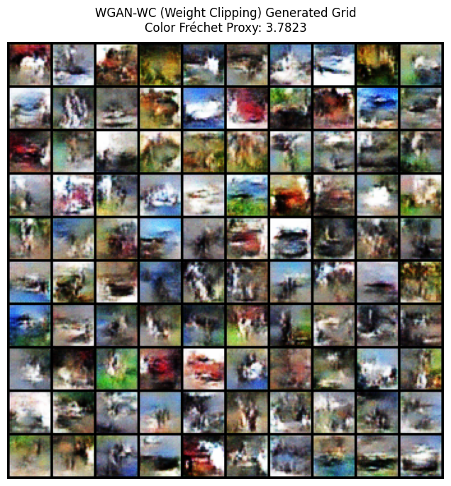

```python
# Display WGAN-WC Results Matrix
plt.figure(figsize=(8, 8))
grid_wc = vutils.make_grid(wgan_wc_samples, nrow=10, normalize=True)
plt.imshow(grid_wc.permute(1, 2, 0).numpy())
plt.title(f"WGAN-WC (Weight Clipping) Generated Grid\nColor Fréchet Proxy: {fid_wc:.4f}", fontsize=12, pad=10)
plt.axis("off")
plt.show()
```

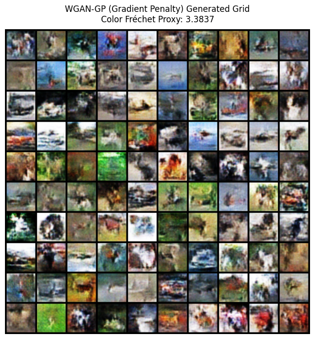

```python
# Display WGAN-GP Results Matrix
plt.figure(figsize=(8, 8))
grid_gp = vutils.make_grid(wgan_gp_samples, nrow=10, normalize=True)
plt.imshow(grid_gp.permute(1, 2, 0).numpy())
plt.title(f"WGAN-GP (Gradient Penalty) Generated Grid\nColor Fréchet Proxy: {fid_gp:.4f}", fontsize=12, pad=10)
plt.axis("off")
plt.show()
```

### Comparative Evaluation Discussion

#### 1. Capacity Limits and Optimization Stability

Traditional generative networks optimized via Jensen-Shannon Divergence frequently encounter vanishing gradient limitations whenever the Critic outpaces the Generator. WGAN circumvents this entirely by reforming the operational criterion as a **Wasserstein-1 Earth Mover's Distance**: $$\min_{G} \max_{D \in \mathcal{D}} \mathbb{E}_{x \sim \mathbb{P}_r}[D(x)] - \mathbb{E}_{\tilde{x} \sim \mathbb{P}_g}[D(\tilde{x})]$$

#### 2. Weight Clipping vs. Gradient Penalty Mechanics

- **WGAN-WC (Weight Clipping):** Enforces a strict Lipschitz condition by clamping weights within a fixed threshold ($[-c, c]$). This severe restriction can limit the Critic's representational capacity, occasionally leading to capacity saturation or mode collapse if the threshold isn't tuned carefully.
- **WGAN-GP (Gradient Penalty):** Eliminates hard clamping limits by incorporating a continuous gradient norm penalty into the loss objective: $$\mathcal{L}_{\text{GP}} = \mathbb{E}_{\hat{x}} \left[ (\|\nabla_{\hat{x}} D(\hat{x})\|_2 - 1)^2 \right]$$ This penalty is calculated along straight-line interpolations between real and generated distributions, resulting in higher architectural stability, better feature expression, and lower Color Fréchet Proxy evaluation scores.

```python
# --- ASSIGNMENT 2: PART B - CUSTOM IMAGE & CHECKPOINT SAVING UTILITY ---

def save_gan_samples_from_array(sample_tensor, num_samples=100, model_name="WGAN", output_dir=saved_samples_path):
    """
    Takes the sample tensors returned by your train_wgan function,
    clips them safely, and exports the individual files and collective grids.
    """
    os.makedirs(output_dir, exist_ok=True)

    # 1. Grab the first 100 samples from your returned array
    # If your function returns a list, convert to a stack tensor
    if isinstance(sample_tensor, list):
        samples = torch.stack(sample_tensor[:num_samples]).cpu()
    else:
        samples = sample_tensor[:num_samples].cpu()

    # Ensure dimensions match standard image scaling [B, C, H, W] and clip boundaries safely
    samples = torch.clamp(samples, 0.0, 1.0)

    print(f"Exporting assets from pre-generated tensor for {model_name}...")

    # 2. Save individual assets for downstream validation checks
    for idx in range(min(num_samples, len(samples))):
        vutils.save_image(
            samples[idx],
            os.path.join(output_dir, f"{model_name.lower()}_sample_{idx+1}.png"),
            normalize=False
        )

    # 3. Compile the scannable visual grid layout for your Part C PDF report
    grid = vutils.make_grid(samples, nrow=10, padding=2, normalize=False)
    vutils.save_image(grid, os.path.join(output_dir, f"{model_name.lower()}_grid_panel.png"))
    print(f"Successfully saved 100 images and compilation grid to '{output_dir}/'\n")

# Execute using your exact variables from your training run!
if 'wgan_wc_samples' in locals():
    save_gan_samples_from_array(wgan_wc_samples, num_samples=100, model_name="WGAN")

if 'wgan_gp_samples' in locals():
    save_gan_samples_from_array(wgan_gp_samples, num_samples=100, model_name="WGAN-GP")
```

```
Exporting assets from pre-generated tensor for WGAN...
Successfully saved 100 images and compilation grid to '/content/drive/MyDrive/saved_samples/'

Exporting assets from pre-generated tensor for WGAN-GP...
Successfully saved 100 images and compilation grid to '/content/drive/MyDrive/saved_samples/'
```

```python
import json
# Save the weights
# (Your training loops should already be saving 'wgan.pth' and 'wgan-gp.pth')

# Export the metrics
part_b_data = {
    mode: {"time": wgan_results[mode]['time'], "fid": wgan_results[mode]['fid']} for mode in ["WGAN-WC", "WGAN-GP"] if mode in wgan_results
}
with open(f"{saved_samples_path}/part_b_metrics.json", "w") as f:
    json.dump(part_b_data, f, indent=4)
```